# Red Wine Quality Exploration

## Effect of Alcohol and Other Attributes on Wine Quality

Furthering the investigation into which attributes affect the quality of wine, I held alcohol as an independent variable to test whether different variables affected the quality of wine.

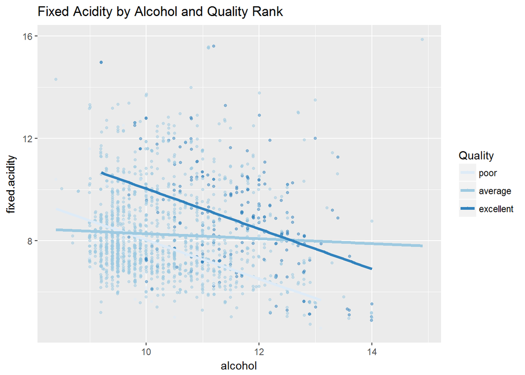

In this relationship, wine quality increases as fixed acidity content increases and alcohol concentration decreases.

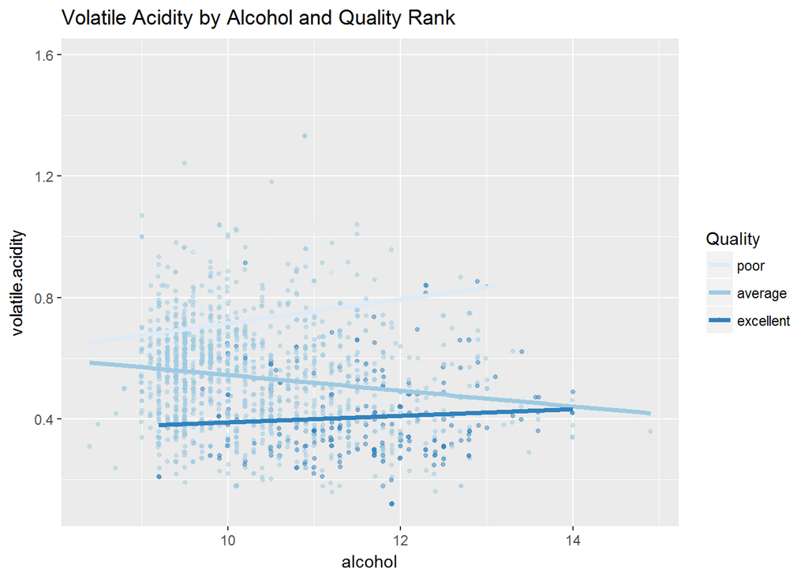

As the amount of volatile acidity decreases and the amount of alcohol increases, the quality of wine seems to increase as well.

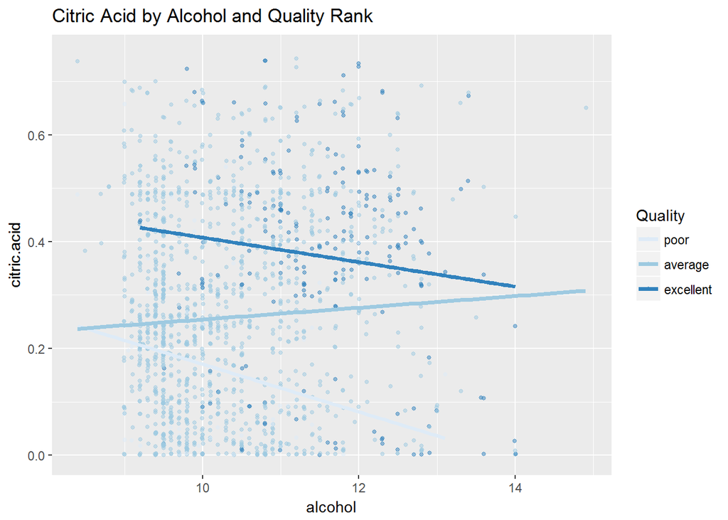

With higher citric acid and lower alcohol concentration, the wine quality increases.

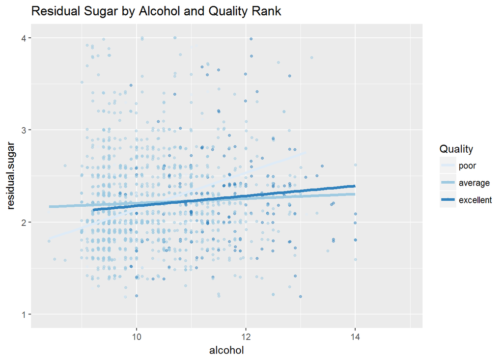

There doesn’t seem to be any correlation with here between residual sugar and quality.

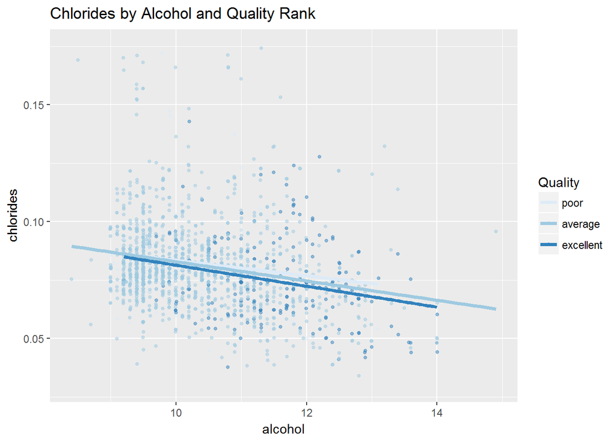

Chlorides behaves in a similar way as residual sugar does with quality.

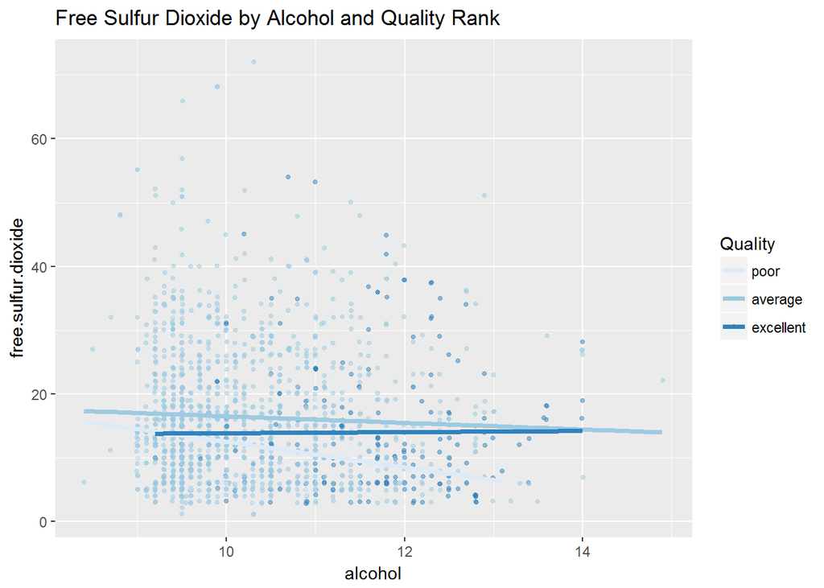

As free sulfur dioxide concentration decreases and alcohol increases, the quality of wine decreases.

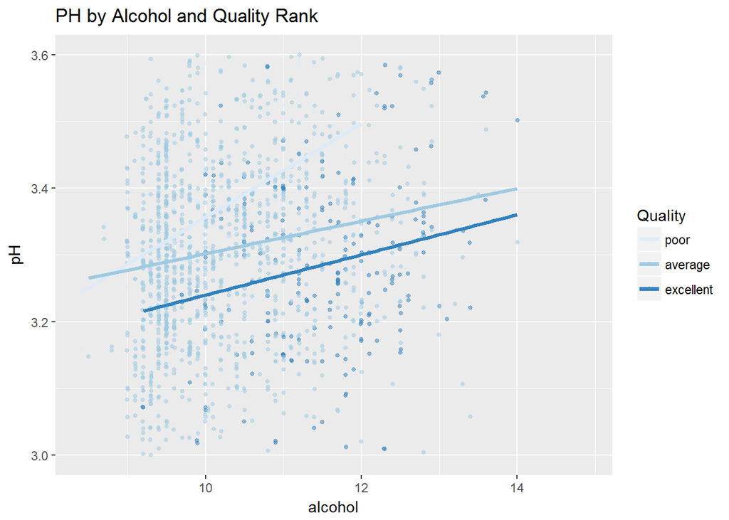

As pH decreases and alcohol concentration increases, wine quality improves.

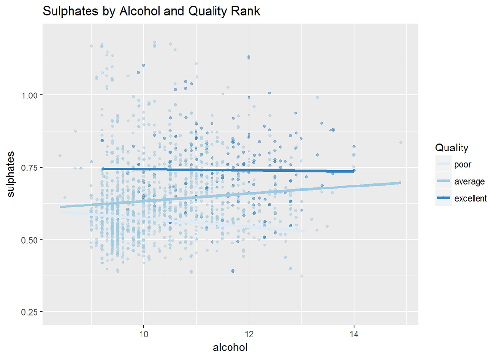

As sulphate concentration increases and alcohol concentration increases, the quality of wine increases as well. Interesting to note how excellent wine seems to hover around .75 sulphates level even at varying values of alcohol.

# Multivariate Analysis

## Linear Modeling

Using the linear model function I was able to build a model to predict the outcome variable, quality, using a handful of explanatory (or predictor) variables in the wine dataset.

```
##
## Call:
## lm(formula = as.numeric(quality) ~ fixed.acidity + volatile.acidity +
##     chlorides + total.sulfur.dioxide + sulphates + alcohol, data = wine_samp)
##
## Residuals:
##      Min       1Q   Median       3Q      Max
## -2.25056 -0.37308 -0.05816  0.43944  1.94517
##
## Coefficients:
##                        Estimate Std. Error t value Pr(>|t|)
## (Intercept)           2.5724016  0.4261914   6.036 3.11e-09 ***
## fixed.acidity         0.0434652  0.0185290   2.346   0.0194 *
## volatile.acidity     -1.1319573  0.1740927  -6.502 1.95e-10 ***
## chlorides            -1.4114831  0.6636815  -2.127   0.0339 *
## total.sulfur.dioxide -0.0009416  0.0009826  -0.958   0.3384
## sulphates             0.8145057  0.1933689   4.212 3.01e-05 ***
## alcohol               0.2821132  0.0305322   9.240  < 2e-16 ***
## ---
## Signif. codes:  0 '***' 0.001 '**' 0.01 '*' 0.05 '.' 0.1 ' ' 1
##
## Residual standard error: 0.6666 on 493 degrees of freedom
## Multiple R-squared:   0.36,  Adjusted R-squared:  0.3522
## F-statistic: 46.21 on 6 and 493 DF,  p-value: < 2.2e-16
```

## Analysis of Linear Model

# Final Plots and Summary

In determining the most significant plots in this investigation on the red wine dataset I approached it from a multi-tiered level since at each section in this investigation, I gleaned insight from previous sections - univariate to bivariate analysis, and bivariate to multivariate analysis.

### Plot One

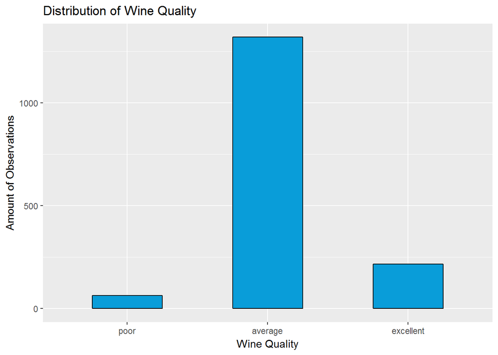

### Description One

I chose plot one because it shows the obvious unbalanced distribution of the dataset in that the bulk of the data falls into the average wine quality bucket.

### Plot Two

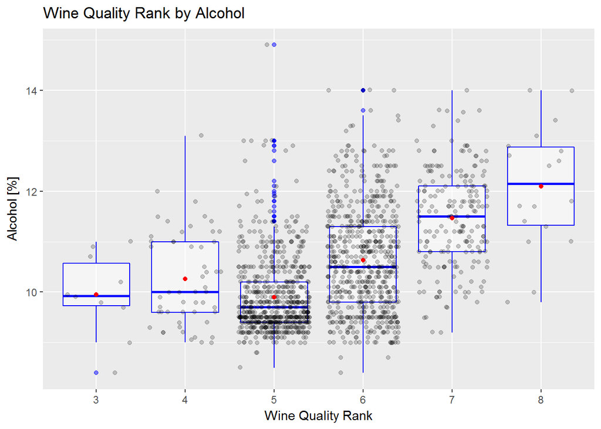

### Description Two

This next plot demonstrated that the amount of alcohol concentration in a particular wine can be a good indicator into the quality of that wine. It’s easy to see that as the percentage of alcohol climbs, there exists a trend for wine quality to climb as well.

### Plot Three

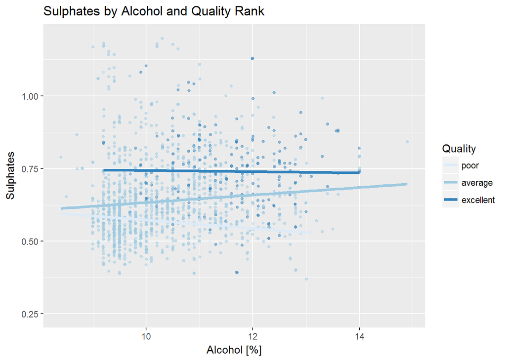

### Description Three

This last plot is of a multivariation relationship demonstrating how better wine quality can be achieved through increased levels of alcohol and sulphates. Previously in the investigation, we knew that alcohol contributed to 22% of the quality of wine. This plot showed that, at least part of the remaining 78%, included sulphates as a contributing determinant to predicting the quality of wine.

# Reflection

This red wine dataset contains 1599 observations with 11 variables on various chemical properties. With the main feature of interest being the quality of wine, this investigation’s objective was to explore the relationship between the rest of the features and the wine quality.

Initial bivariate exploration revealed that only a handful of features hold a reasonable correlation to the wine quality. For the purposes of this investigation, the top 4 most highest correlation coefficients to quality - alcohol, volatile acidity, sulphates, and citric acid - were used in much of the data visualizations.

It was surprising to me how some of the other features aren’t strongly correlated with the wine quality. I would assume pH, for example, would play a big role into determining the quality of wine.

Another surprise / struggle appeared when I realized the uneven distribution of observations across the 3 levels of wine quality ranking - poor, average, excellent. We saw how in the linear model for predicting wine quality, the traditional approach for using R squared values as a gauge for model effectiveness did not work with this particular dataset (since all the values of models were well below acceptance ranges). A data collection effort to include more wines from poor and excellent rankings would go a long way in improving the capability of models for predicting the quality of wine.

In terms of the future work to be done for improving the dataset, including different components of red wine into the data could help lead to more powerful linear models as well. For example, I’m curious to see how age would affect the quality of wines. Is older-aged wine really worth the bump in retail tag? Or does the price of wine help determine the quality? These questions could help spark an effort to form a dataset with the potential to gain insight and strong conclusions from.